# DataHw1-Qn2

Charls Joseph

March 26, 2020

## Load the ‘junk1.txt’ file.

There are 100 observation with 3 columns.

```r
library(VIM)
df <- read.csv("C:\\Users\\Charls\\Documents\\CunyMSDS\\Data622\\Assignments\\HW1\\Qn2\\junk1.txt", header = T, sep = ' ')
dim(df)
```

```
## [1] 100   3
```

## EDA for dataset ’junk1.txt"

The given dataset is balanced(i.e both classes are evenly distributed.) a is a numeric value ranges from -2.2 to 3 b is a numeric value ranges from -3.1 to 3 class - 1, 2

Note: Need to know the metadata for this dataset

```r
table(df$class)
```

```
##
##  1  2
## 50 50
```

```r
summary(df)
```

```
##        a                  b                class
##  Min.   :-2.29854   Min.   :-3.17174   Min.   :1.0
##  1st Qu.:-0.85014   1st Qu.:-1.04712   1st Qu.:1.0
##  Median :-0.04754   Median :-0.07456   Median :1.5
##  Mean   : 0.04758   Mean   : 0.01324   Mean   :1.5
##  3rd Qu.: 1.09109   3rd Qu.: 1.05342   3rd Qu.:2.0
##  Max.   : 3.00604   Max.   : 3.10230   Max.   :2.0
```

Using boxplot, determine whether there is any outliers. No outliers are found.

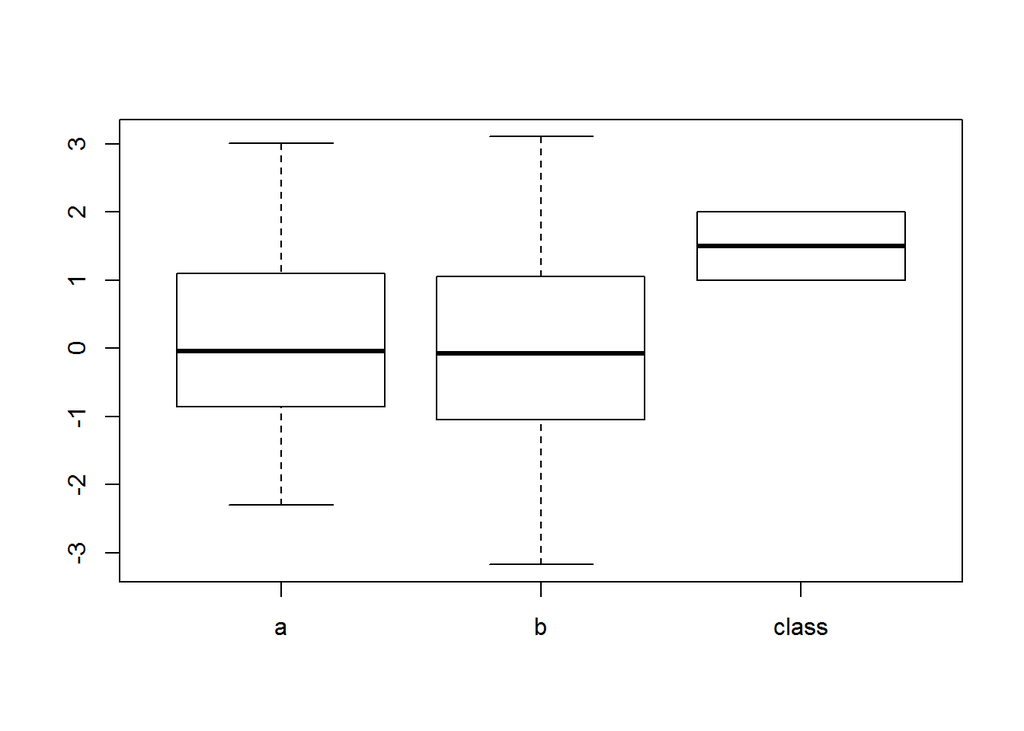

```r
boxplot(df)
```

Using aggr plot, we dont see any missing values.

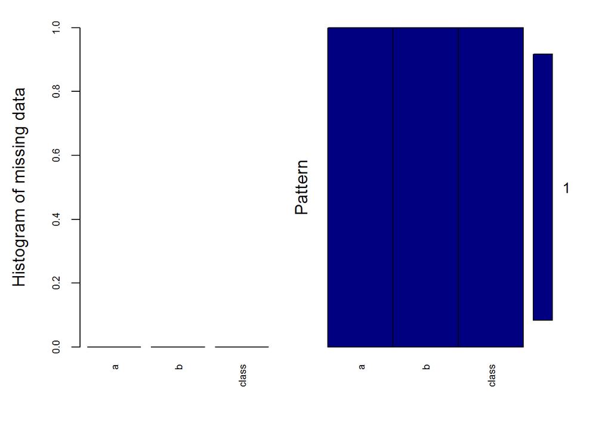

```
##
##  Variables sorted by number of missings:
##  Variable Count
##         a     0
##         b     0
##     class     0
```

```r
aggr_plot <- aggr(df, col=c('navyblue','red'), numbers=TRUE, sortVars=TRUE, labels=names(df), cex.axis=.7, gap=3, ylab=c("Histogram of missing data","Pattern"))
```

## Load the ‘junk2.csv’ file.

There are 4000 Observations with 3 columns.

```r
df1 <- read.csv("C:\\Users\\Charls\\Documents\\CunyMSDS\\Data622\\Assignments\\HW1\\Qn2\\junk2.csv", header = T, sep = ',')

dim(df1)
```

```
## [1] 4000    3
```

The given dataset is imbalanced(i.e both classes are not evenly distributed.) a is a numeric value ranges from -4.1 to 4.6 b is a numeric value ranges from -3.9 to 4.31 class - 0, 1

Note: 1. Need to know the metadata for this dataset. What are variable a, b and class in business terms.

2. It would be great if we can get a balanced dataset if possible.
3. Assuming that the given dataset is based on a normal distribution, the response variable is always imbalanced. So I would ask business which performance metrics i should try to improve. Whether it is Type1 error/Precision or type2/Recall while evalvating the model performance. This is very crucial for determining the optimal value of threshold for classification.

```r
table(df1$class)
```

```
##
##    0    1
## 3750  250
```

```r
summary(df1)
```

```
##        a                  b                class
##  Min.   :-4.16505   Min.   :-3.90472   Min.   :0.0000
##  1st Qu.:-1.01447   1st Qu.:-0.89754   1st Qu.:0.0000
##  Median : 0.08754   Median :-0.08358   Median :0.0000
##  Mean   :-0.05126   Mean   : 0.05624   Mean   :0.0625
##  3rd Qu.: 0.89842   3rd Qu.: 1.00354   3rd Qu.:0.0000
##  Max.   : 4.62647   Max.   : 4.31052   Max.   :1.0000
```

Using boxplots, we are seeing some outliers for both a, b variable. Extract those and ask business team that they are all genuine and determine the need of removing it from the dataset.

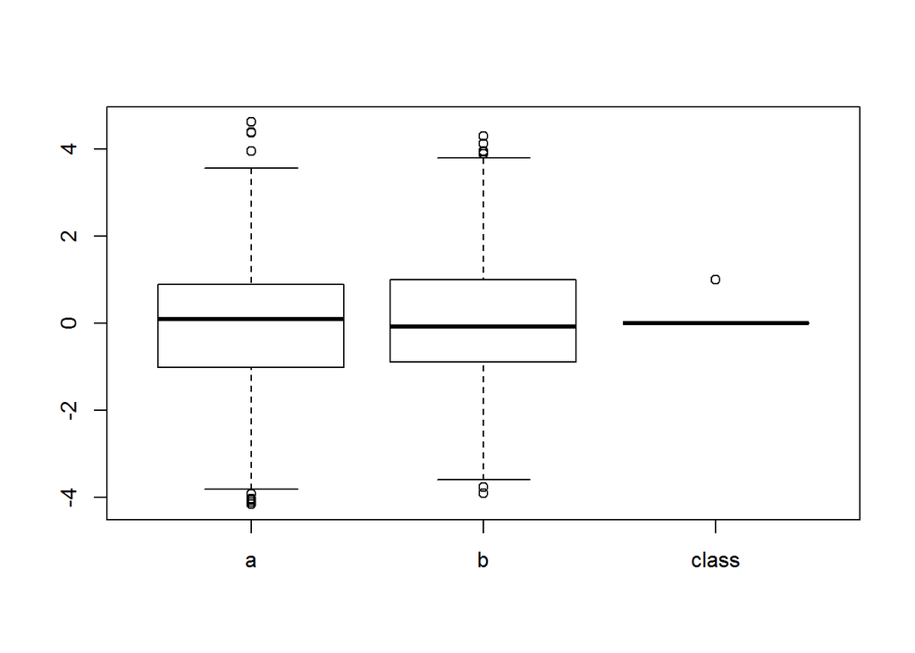

```r
boxplot(df1)
```

There is no missing values

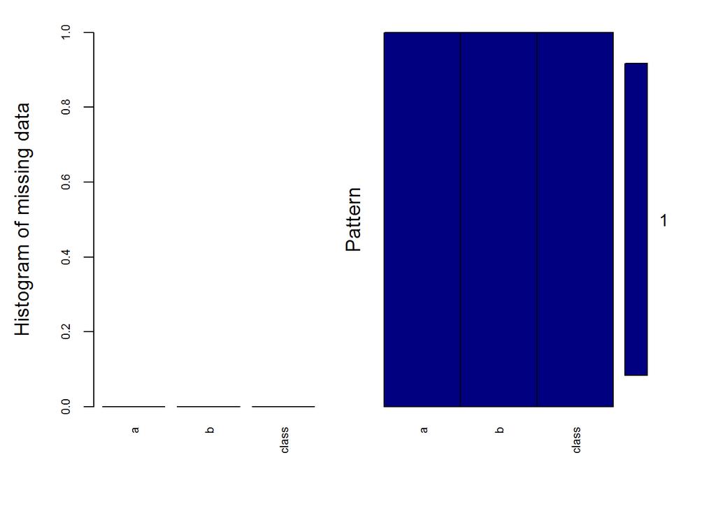

```
##
##  Variables sorted by number of missings:
##  Variable Count
##         a     0
##         b     0
##     class     0
```

```r
aggr_plot <- aggr(df1, col=c('navyblue','red'), numbers=TRUE, sortVars=TRUE, labels=names(df1), cex.axis=.7, gap=3, ylab=c("Histogram of missing data","Pattern"))
```